# Platelets gene analysis

Data were processed with the nf-core RNA-seq pipeline https://github.com/nf-core/rnaseq which includes STAR and salmon. Further analysis was performed using the R package DEseq2.

**Differential expression analysis overview:**

RPs vs MPs - CCS only - design = ~ RPs.MPs + patient (DE between RPs/MPs with paired patients) - data: 38 CCS samples - DE statistics for all genes: results/ccs_rp_vs_mp_diff_gene_counts.xlsx - only significant genes: results/ccs_rp_vs_mp_sign_diff_gene_counts.xlsx - gene set enrichment: results/ccs_rp_vs_mp_sign_gene_set_enrichment.xlsx

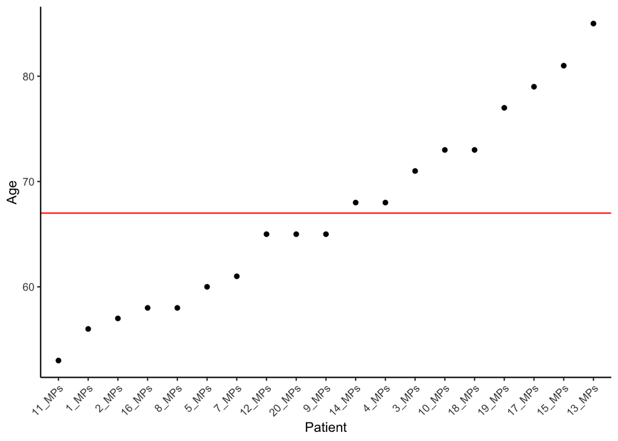

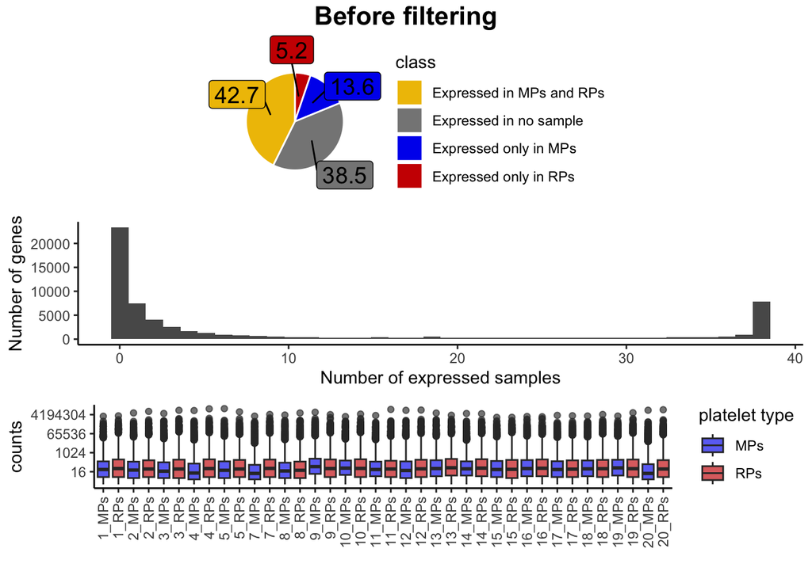

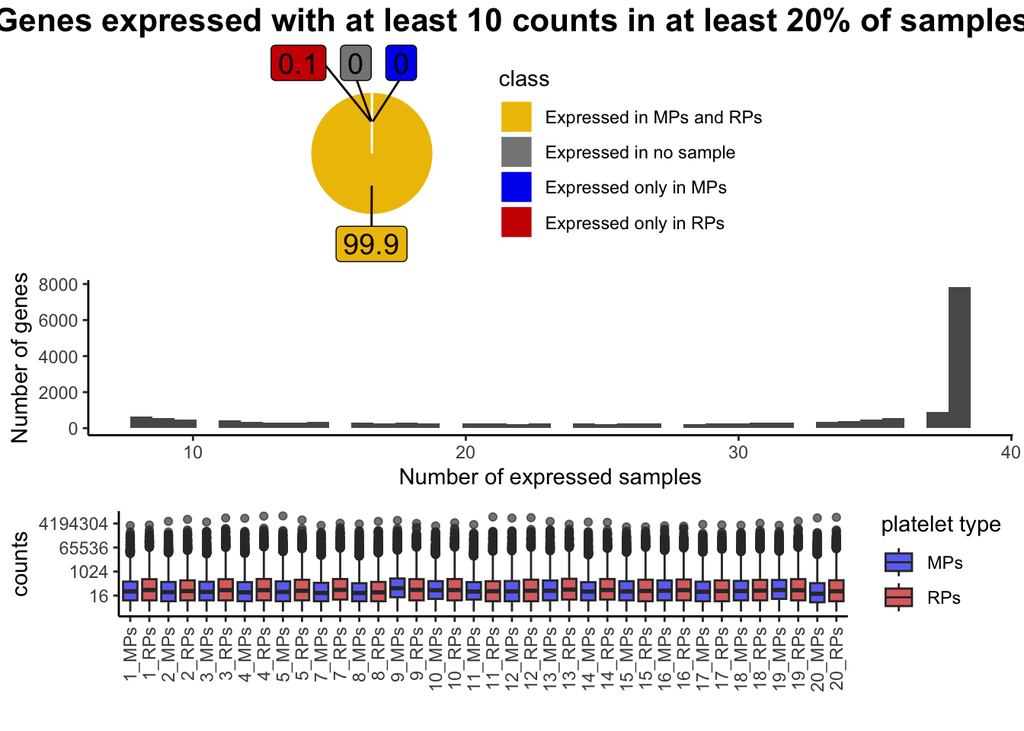

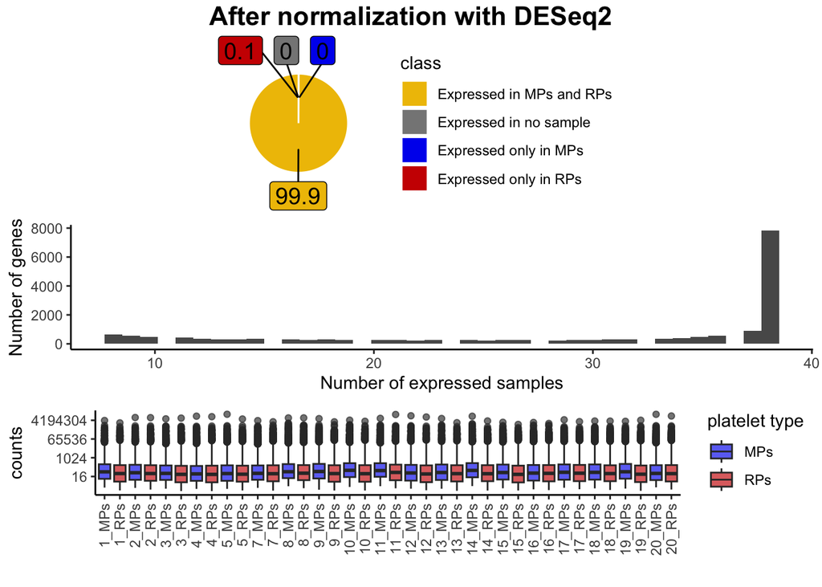

[figure not shown]

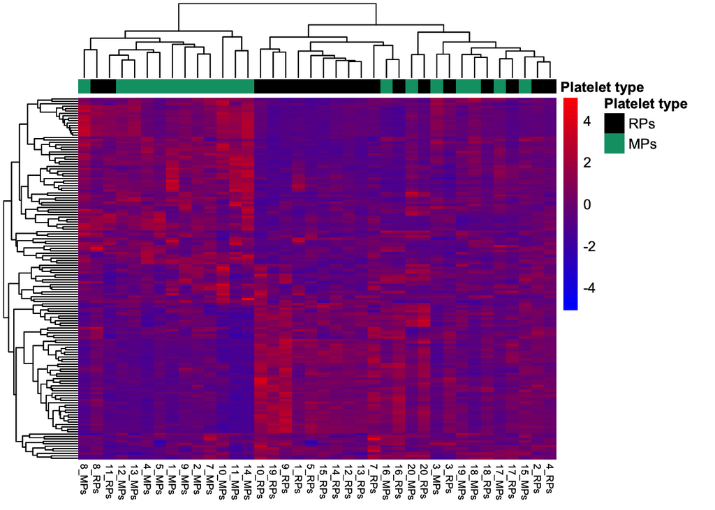

```r
threshold <- sort(rowVars(dds_ccs_counts), decreasing = T)[150]
dds_ccs_top = dds_ccs_counts[which(rowVars(dds_ccs_counts) >= threshold),]
plot <- pheatmap(dds_ccs_top,
                 fontsize_col = 7,
                 color = colorRampPalette(c("blue", "red"))(50),
                 border_color = NA,
                 annotation_colors = list(`Platelet type` = c(RPs = cbbPalette[1], MPs = cbbPalette[4])),
                 annotation_col = metadata_ccs %>% dplyr::select(`Platelet type` = RPs_MPs),
                 show_rownames = FALSE,
                 show_colnames = TRUE,
                 scale="row")
rm(threshold, dds_ccs_top)

ggsave(plot = plot, path ='plots', filename = paste0("CCS_only_heatmap_top150", version, ".png"),
       width = plot_width, height = plot_height, dpi = plot_res, units = "in", device='png')
ggsave(plot = plot, path ='plots/pdf', filename = paste0("CCS_only_heatmap_top150", version, ".pdf"),
       width = plot_width, height = plot_height, dpi = plot_res, units = "in", device='pdf')
plot
```

```r
dds_ccs_results <- as.data.frame(dds_ccs_results)
dds_ccs_results <- merge(dds_ccs_results, id2symbol, by.x = 0, by.y = 'ensg')
rownames(dds_ccs_results) <- dds_ccs_results$Row.names
dds_ccs_results <- dds_ccs_results[,c("hgnc_symbol", "baseMean", "log2FoldChange", "lfcSE", "stat", "pvalue", "padj", "gene_biotype")]
dds_ccs_results <- dds_ccs_results[order(dds_ccs_results[,'padj']),]

#write.xlsx2(dds_ccs_results, paste0("results/ccs_rp_vs_mp_diff_gene_counts", version, ".xlsx"))
DT::datatable(dds_ccs_results)
```

|  | hgnc_symbol | baseMean | log2FoldChange | lfcSE | stat | pvalue | padj | gene_biotype |
| --- | --- | --- | --- | --- | --- | --- | --- | --- |
| ENSG00000071054 | MAP4K4 | 1415.420640267398 | 0.7347895875450644 | 0.0481331140436819 | 15.26578120165311 | 1.292703661526904e-52 | 1.879720394226271e-48 | protein_coding |
| ENSG00000160789 | LMNA | 4306.785091288905 | 1.209099661627404 | 0.08056928208564638 | 15.00695588105294 | 6.611298518993793e-51 | 4.806744588234438e-47 | protein_coding |
| ENSG00000142961 | MOB3C | 1124.701867666349 | 1.583202071313385 | 0.1068953969020649 | 14.81076002518498 | 1.24820943868297e-49 | 6.050071149296357e-46 | protein_coding |
| ENSG00000197852 | INKA2 | 302.9197018409654 | 1.893722054735722 | 0.1282226780574824 | 14.76901031412527 | 2.320960540280176e-49 | 8.43727180405351e-46 | protein_coding |
| ENSG00000088888 | MAVS | 1057.898049933215 | 1.53232843577354 | 0.1043814168465458 | 14.68008848764969 | 8.64775304822376e-49 | 2.514939541484434e-45 | protein_coding |
| ENSG00000127603 | MACF1 | 5043.133167420236 | 1.092774615739018 | 0.07478383953147384 | 14.61244331108606 | 2.339740875533056e-48 | 5.670362011854361e-45 | protein_coding |
| ENSG00000015133 | CCDC88C | 854.3267364288206 | 1.066916553057966 | 0.0735802744391291 | 14.50003497799667 | 1.210881764909135e-47 | 2.51534739193482e-44 | protein_coding |
| ENSG00000187800 | PEAR1 | 2553.006911926366 | 1.343234629895941 | 0.09404182627802976 | 14.28337456914902 | 2.778160993385331e-46 | 5.049654875602013e-43 | protein_coding |
| ENSG00000182253 | SYNM | 2207.932970543316 | 0.8745047702537523 | 0.06135023941089394 | 14.25430085768283 | 4.215024031617464e-46 | 6.810073827083284e-43 | protein_coding |
| ENSG00000167110 | GOLGA2 | 878.4649286098384 | 1.308171345862959 | 0.09312102577475166 | 14.0480770586362 | 7.915423911887494e-45 | 1.15098179102756e-41 | protein_coding |

[output cut: 14531 more lines]

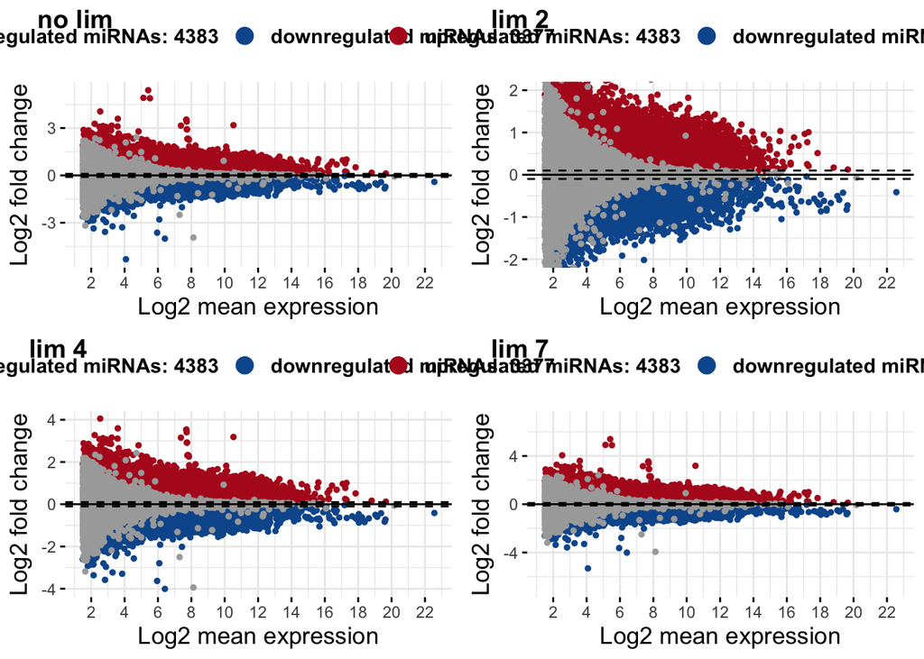

```r
fdr <- 0.1
fc <- 1

plot_nolim <- myMAplot(dds_ccs_results, fdr = fdr, fc = fc)
ggsave(plot = plot_nolim, path ='plots', filename = paste0("CCS_only_ma_noLim", version, ".png"),
       width = plot_width, height = plot_height, dpi = plot_res, units = "in", device='png')
ggsave(plot = plot_nolim, path ='plots/pdf', filename = paste0("CCS_only_ma_noLim", version, ".pdf"),
       width = plot_width, height = plot_height, dpi = plot_res, units = "in", device='pdf')

plot_lim2 <- myMAplot_lim(dds_ccs_results, fdr = fdr, fc = fc, ylim = c(-2, 2))
ggsave(plot = plot_lim2, path ='plots', filename = paste0("CCS_only_ma_lim2", version, ".png"),
       width = plot_width, height = plot_height, dpi = plot_res, units = "in", device='png')
ggsave(plot = plot_lim2, path ='plots/pdf', filename = paste0("CCS_only_ma_lim2", version, ".pdf"),
       width = plot_width, height = plot_height, dpi = plot_res, units = "in", device='pdf')

plot_lim4 <- myMAplot_lim(dds_ccs_results, fdr = fdr, fc = fc, ylim = c(-4, 4))
ggsave(plot = plot_lim4, path ='plots', filename = paste0("CCS_only_ma_lim4", version, ".png"),
       width = plot_width, height = plot_height, dpi = plot_res, units = "in", device='png')
ggsave(plot = plot_lim4, path ='plots/pdf', filename = paste0("CCS_only_ma_lim4", version, ".pdf"),
       width = plot_width, height = plot_height, dpi = plot_res, units = "in", device='pdf')

plot_lim7 <- myMAplot_lim(dds_ccs_results, fdr = fdr, fc = fc, ylim = c(-7, 7))
ggsave(plot = plot_lim7, path ='plots', filename = paste0("CCS_only_ma_lim7", version, ".png"),
       width = plot_width, height = plot_height, dpi = plot_res, units = "in", device='png')
ggsave(plot = plot_lim7, path ='plots/pdf', filename = paste0("CCS_only_ma_lim7", version, ".pdf"),
       width = plot_width, height = plot_height, dpi = plot_res, units = "in", device='pdf')

plot <- ggarrange(plot_nolim, plot_lim2, plot_lim4, plot_lim7, labels = c("no lim", "lim 2", "lim 4", "lim 7"), ncol = 2, nrow = 2)
rm(plot_nolim, plot_lim2, plot_lim4, plot_lim7)
plot
```

Next, we show a heatmap focusing only on the top 20, 50 and 100 differentially expressed genes having the smallest p-values from the above list.

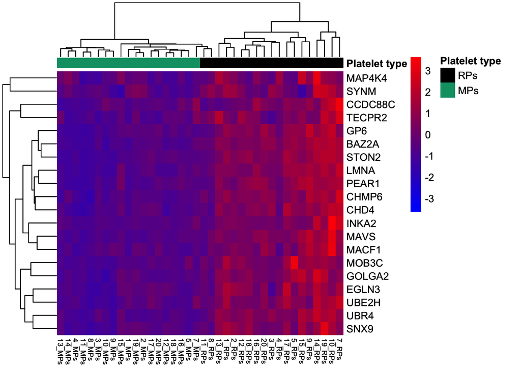

```r
top_20 <- dds_ccs_counts[rownames(dds_ccs_results)[1:20],]
rownames(top_20) <- dds_ccs_results$hgnc_symbol[1:20]
plot <- pheatmap(top_20,
                 fontsize_col = 7,
                 fontsize_row = 10,
                 color = colorRampPalette(c("blue", "red"))(50),
                 border_color = NA,
                 annotation_colors = list(`Platelet type` = c(RPs = cbbPalette[1], MPs = cbbPalette[4])),
                 annotation_col = metadata_ccs %>% dplyr::select(`Platelet type` = RPs_MPs),
                 show_rownames = TRUE,
                 show_colnames = TRUE,
                 scale="row")
rm(top_20)

ggsave(plot = plot, path ='plots', filename = paste0("CCS_only_heatmap_top20", version, ".png"),
       width = plot_width, height = plot_height, dpi = plot_res, units = "in", device='png')
ggsave(plot = plot, path ='plots/pdf', filename = paste0("CCS_only_heatmap_top20", version, ".pdf"),
       width = plot_width, height = plot_height, dpi = plot_res, units = "in", device='pdf')
plot
```

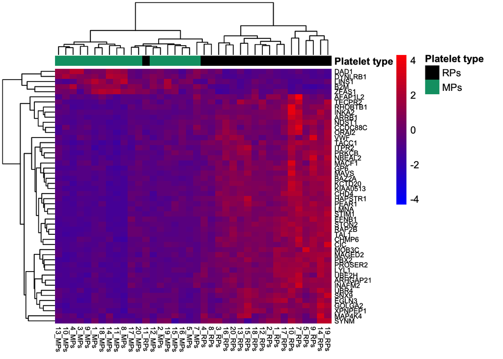

```r
top_50 <- dds_ccs_counts[rownames(dds_ccs_results)[1:50],]
rownames(top_50) <- dds_ccs_results$hgnc_symbol[1:50]
plot <- pheatmap(top_50,
                 fontsize_col = 7,
                 fontsize_row = 7,
                 color = colorRampPalette(c("blue", "red"))(50),
                 border_color = NA,
                 annotation_colors = list(`Platelet type` = c(RPs = cbbPalette[1], MPs = cbbPalette[4])),
                 annotation_col = metadata_ccs %>% dplyr::select(`Platelet type` = RPs_MPs),
                 show_rownames = TRUE,
                 show_colnames = TRUE,
                 scale="row")
rm(top_50)

ggsave(plot = plot, path ='plots', filename = paste0("CCS_only_heatmap_top50", version, ".png"),
       width = plot_width, height = plot_height, dpi = plot_res, units = "in", device='png')
ggsave(plot = plot, path ='plots/pdf', filename = paste0("CCS_only_heatmap_top50", version, ".pdf"),
       width = plot_width, height = plot_height, dpi = plot_res, units = "in", device='pdf')
plot
```

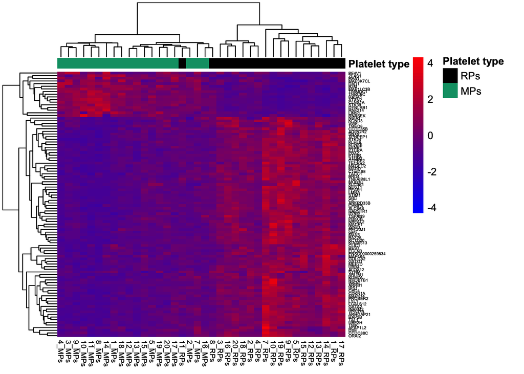

```r
top_100 <- dds_ccs_counts[rownames(dds_ccs_results)[1:100],]
rownames(top_100) <- dds_ccs_results$hgnc_symbol[1:100]
plot <- pheatmap(top_100,
                 fontsize_col = 7,
                 fontsize_row = 4,
                 color = colorRampPalette(c("blue", "red"))(50),
                 border_color = NA,
                 annotation_colors = list(`Platelet type` = c(RPs = cbbPalette[1], MPs = cbbPalette[4])),
                 annotation_col = metadata_ccs %>% dplyr::select(`Platelet type` = RPs_MPs),
                 show_rownames = TRUE,
                 show_colnames = TRUE,
                 scale="row")
rm(top_100)

ggsave(plot = plot, path ='plots', filename = paste0("CCS_only_heatmap_top100", version, ".png"),
       width = plot_width, height = plot_height, dpi = plot_res, units = "in", device='png')
ggsave(plot = plot, path ='plots/pdf', filename = paste0("CCS_only_heatmap_top100", version, ".pdf"),
       width = plot_width, height = plot_height, dpi = plot_res, units = "in", device='pdf')
plot
```

Here, the samples are colored by platelet type and labeled by patient.

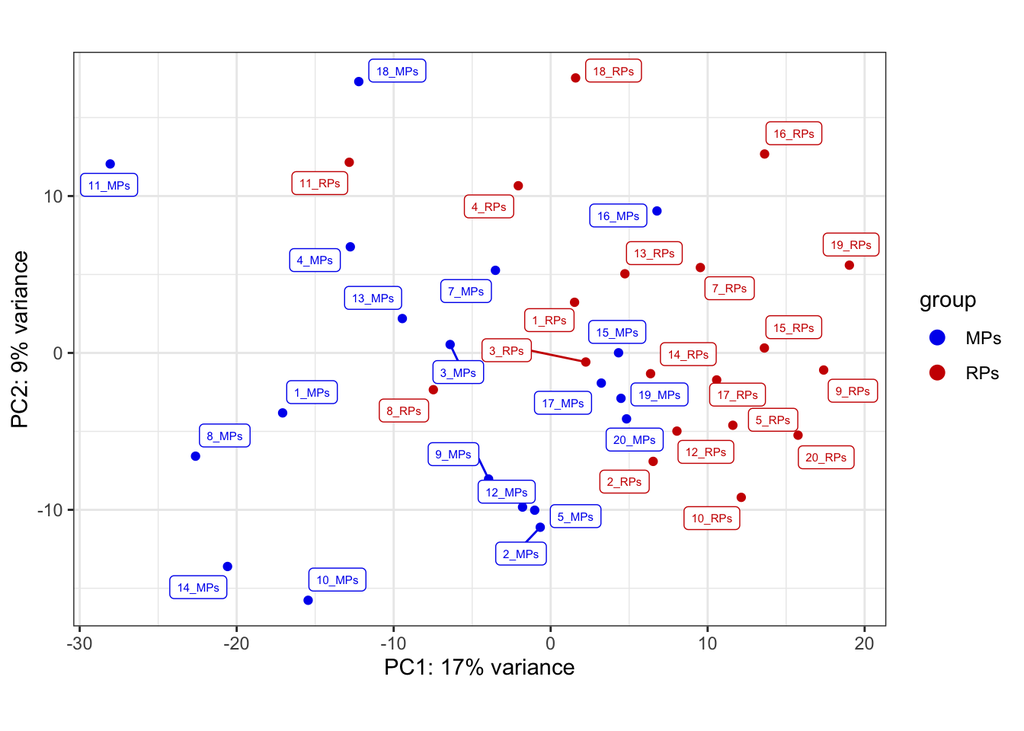

```r
plot <- myPCAplot(vst(dds_ccs), intgroup = "RPs_MPs") +
          geom_label_repel(aes(label=colnames(dds_ccs)), size = 2, show.legend = FALSE)

ggsave(plot = plot, path ='plots', filename = paste0("CCS_only_pca_RPvsMP", version, ".png"),
       width = plot_width, height = plot_height, dpi = plot_res, units = "in", device='png')
ggsave(plot = plot, path ='plots/pdf', filename = paste0("CCS_only_pca_RPvsMP", version, ".pdf"),
       width = plot_width, height = plot_height, dpi = plot_res, units = "in", device='pdf')
plot
```

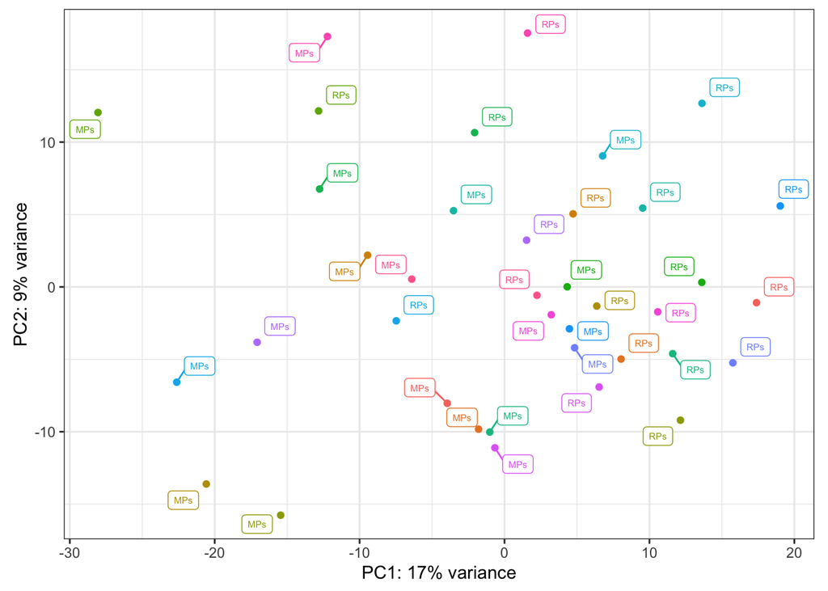

```r
plot <- myPCAplot(vst(dds_ccs), intgroup = c("patient")) +
          geom_label_repel(aes(label=RPs_MPs), size = 2) +
          theme(legend.position="none")

ggsave(plot = plot, path ='plots', filename = paste0("CCS_only_pca_patiens", version, ".png"),
       width = plot_width, height = plot_height, dpi = plot_res, units = "in", device='png')
ggsave(plot = plot, path ='plots/pdf', filename = paste0("CCS_only_pca_patiens", version, ".pdf"),
       width = plot_width, height = plot_height, dpi = plot_res, units = "in", device='pdf')
plot
```

## Differentially expressed genes in CCS

Below we list the significant differentially expressed genes between RPs and MPs when matching patients. (abs(log2FC) > 1, padj < 0.1)

```r
FCcutoff <- 1
pCutoff <- 0.1
write.table(rownames(dds_ccs_results), paste0("../data/GO_analysis/reference_genes_ccs_only", version, ".txt"),
            sep = ",", quote = FALSE, row.names = FALSE, col.names = FALSE)

upregulated_genes <- dds_ccs_results %>%
  filter(log2FoldChange > FCcutoff, padj < pCutoff) %>%
  arrange(padj)
write.table(rownames(upregulated_genes),
            paste0("../data/GO_analysis/sign_upregulated_genes_padj", pCutoff, "_ccs_only", version, ".txt"),
            sep = ",", quote = FALSE, row.names = FALSE, col.names = FALSE)

downregulated_genes <- dds_ccs_results %>%
  filter(log2FoldChange < -FCcutoff, padj < pCutoff) %>%
  arrange(padj)
write.table(rownames(downregulated_genes),
            paste0("../data/GO_analysis/sign_downregulated_genes_padj", pCutoff, "_ccs_only", version, ".txt"),
            sep = ",", quote = FALSE, row.names = FALSE, col.names = FALSE)

dds_ccs_sign_results <- dds_ccs_results %>%
  tibble::rownames_to_column() %>%
  filter(abs(log2FoldChange) > FCcutoff, padj < pCutoff) %>%
  arrange(padj)
#write.xlsx2(dds_ccs_sign_results, paste0("results/ccs_rp_vs_mp_sign_diff_padj_", pCutoff, "_gene_counts", version, ".xlsx"), row.names = F)
DT::datatable(dds_ccs_sign_results)
```

|  | rowname | hgnc_symbol | baseMean | log2FoldChange | lfcSE | stat | pvalue | padj | gene_biotype |
| --- | --- | --- | --- | --- | --- | --- | --- | --- | --- |
| 1 | ENSG00000160789 | LMNA | 4306.785091288905 | 1.209099661627404 | 0.08056928208564638 | 15.00695588105294 | 6.611298518993793e-51 | 4.806744588234438e-47 | protein_coding |
| 2 | ENSG00000142961 | MOB3C | 1124.701867666349 | 1.583202071313385 | 0.1068953969020649 | 14.81076002518498 | 1.24820943868297e-49 | 6.050071149296357e-46 | protein_coding |
| 3 | ENSG00000197852 | INKA2 | 302.9197018409654 | 1.893722054735722 | 0.1282226780574824 | 14.76901031412527 | 2.320960540280176e-49 | 8.43727180405351e-46 | protein_coding |
| 4 | ENSG00000088888 | MAVS | 1057.898049933215 | 1.53232843577354 | 0.1043814168465458 | 14.68008848764969 | 8.64775304822376e-49 | 2.514939541484434e-45 | protein_coding |
| 5 | ENSG00000127603 | MACF1 | 5043.133167420236 | 1.092774615739018 | 0.07478383953147384 | 14.61244331108606 | 2.339740875533056e-48 | 5.670362011854361e-45 | protein_coding |
| 6 | ENSG00000015133 | CCDC88C | 854.3267364288206 | 1.066916553057966 | 0.0735802744391291 | 14.50003497799667 | 1.210881764909135e-47 | 2.51534739193482e-44 | protein_coding |
| 7 | ENSG00000187800 | PEAR1 | 2553.006911926366 | 1.343234629895941 | 0.09404182627802976 | 14.28337456914902 | 2.778160993385331e-46 | 5.049654875602013e-43 | protein_coding |
| 8 | ENSG00000167110 | GOLGA2 | 878.4649286098384 | 1.308171345862959 | 0.09312102577475166 | 14.0480770586362 | 7.915423911887494e-45 | 1.15098179102756e-41 | protein_coding |
| 9 | ENSG00000176108 | CHMP6 | 405.2943388220918 | 1.146285891942242 | 0.08224301726920843 | 13.93778985746682 | 3.733226128790501e-44 | 4.934985558067517e-41 | protein_coding |
| 10 | ENSG00000127481 | UBR4 | 1601.103997488263 | 1.083501865710818 | 0.07788839964805284 | 13.91095298666731 | 5.435042146217696e-44 | 6.278735893827905e-41 | protein_coding |

[output cut: 2409 more lines]

Volcano plot of the significant differences, here filtered for log2 FC +-1 and p-adj < 1e-15.

```r
FCcutoff <- 1
pCutoff <- 1e-15

upregulated_genes <- dds_ccs_results[dds_ccs_results$log2FoldChange > FCcutoff & dds_ccs_results$padj < pCutoff, ]
upregulated_genes <- upregulated_genes[order(upregulated_genes$padj, decreasing = FALSE), ]
write.table(rownames(upregulated_genes),
            paste0("../data/GO_analysis/sign_upregulated_genes_padj", pCutoff, "_ccs_only", version, ".txt"),
            sep = ",", quote = FALSE, row.names = FALSE, col.names = FALSE)

downregulated_genes <- dds_ccs_results[dds_ccs_results$log2FoldChange < -FCcutoff & dds_ccs_results$padj < pCutoff, ]
downregulated_genes <- downregulated_genes[order(downregulated_genes$padj, decreasing = FALSE), ]
write.table(rownames(downregulated_genes),
            paste0("../data/GO_analysis/sign_downregulated_genes_padj", pCutoff, "_ccs_only", version, ".txt"),
            sep = ",", quote = FALSE, row.names = FALSE, col.names = FALSE)


labs_of_interest <- c("GP6", "PEAR1", "VWF", "PKN2", "LUC7L3", "PARN", "ORAI2", "STIM1", "TBXA2R",
                                "F2RL3", "P2RX1", "GP5", "ITGA5", "GPVI", "PEAR")

cat(paste0("Number of IDs of interest in current data: ", length(labs_of_interest[labs_of_interest %in% dds_ccs_results$hgnc_symbol]), "\nList of detected IDs of interes: "))
```

```
## Number of IDs of interest in current data: 13
## List of detected IDs of interes:
```

```r
cat(labs_of_interest[labs_of_interest %in% dds_ccs_results$hgnc_symbol])
```

```
## GP6 PEAR1 VWF PKN2 LUC7L3 PARN ORAI2 STIM1 TBXA2R F2RL3 P2RX1 GP5 ITGA5
```

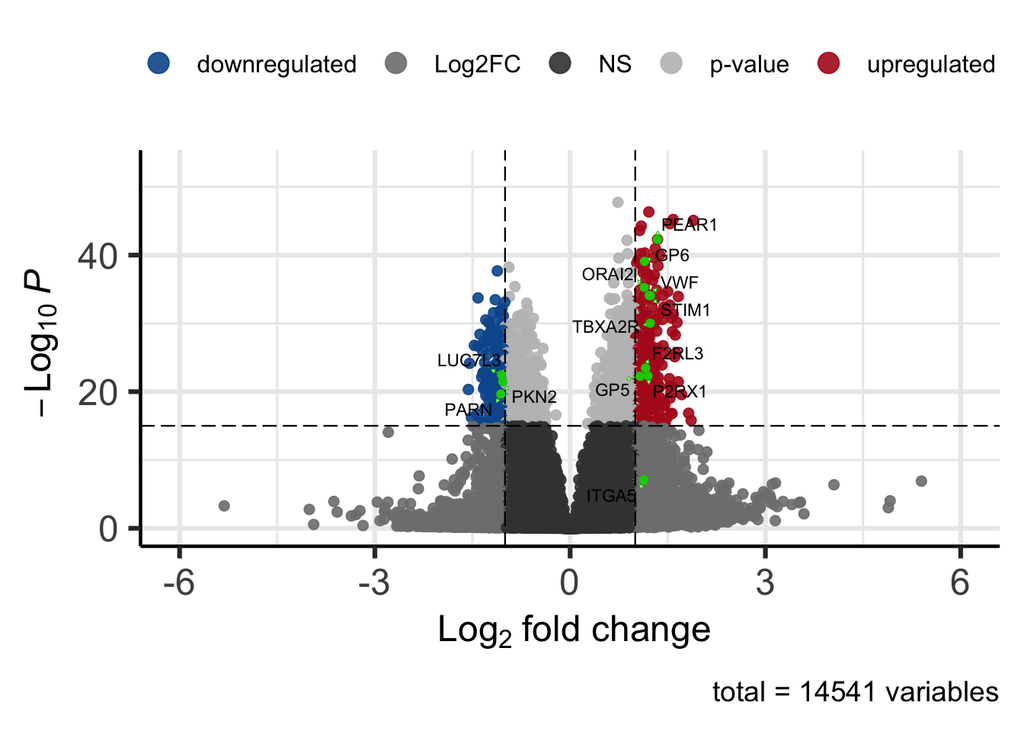

```r
plot <- myVolcanoPlot(dds_ccs_results,
                      data_type = "gene",
                      pCutoff = pCutoff,
                      FCcutoff = FCcutoff,
                      xlim = c(-6, 6),
                      lab_selection = labs_of_interest)

ggsave(plot = plot, path ='plots', filename = paste0("CCS_only_volcano_geneset", version, ".png"),
       width = plot_width, height = plot_height, dpi = plot_res, units = "in", device='png')
ggsave(plot = plot, path ='plots/pdf', filename = paste0("CCS_only_volcano_geneset", version, ".pdf"),
       width = plot_width, height = plot_height, dpi = plot_res, units = "in", device='pdf')
plot
```

```r
regulated_labs_of_interest <- labs_of_interest[labs_of_interest %in% c(upregulated_genes$hgnc_symbol, downregulated_genes$hgnc_symbol)]

cat(paste0("Number of regulated IDs of interest in current data: ", length(regulated_labs_of_interest), "\nList of detected IDs of interes: "))
```

```
## Number of regulated IDs of interest in current data: 12
## List of detected IDs of interes:
```

```r
cat(regulated_labs_of_interest)
```

```
## GP6 PEAR1 VWF PKN2 LUC7L3 PARN ORAI2 STIM1 TBXA2R F2RL3 P2RX1 GP5
```

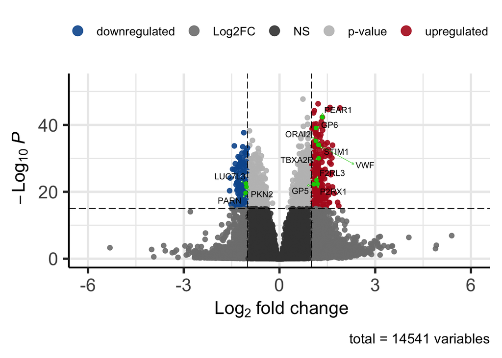

```r
plot <- myVolcanoPlot(dds_ccs_results,
                      data_type = "gene",
                      pCutoff = pCutoff,
                      FCcutoff = FCcutoff,
                      xlim = c(-6, 6),
                      lab_selection = regulated_labs_of_interest)

ggsave(plot = plot, path ='plots', filename = paste0("CCS_only_volcano_regGeneset", version, ".png"),
       width = plot_width, height = plot_height, dpi = plot_res, units = "in", device='png')
ggsave(plot = plot, path ='plots/pdf', filename = paste0("CCS_only_volcano_regGeneset", version, ".pdf"),
       width = plot_width, height = plot_height, dpi = plot_res, units = "in", device='pdf')
plot
```

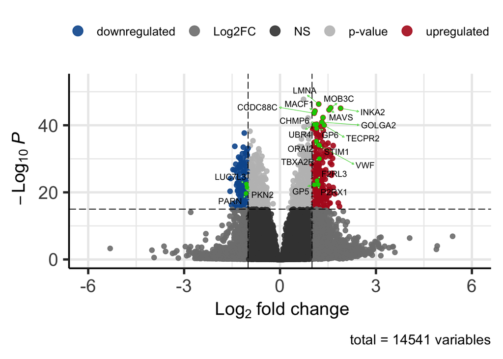

```r
top_10_upregulated_without_labs_of_interest <- as.character(upregulated_genes[!(upregulated_genes$hgnc_symbol %in% labs_of_interest),"hgnc_symbol"])[1:10]
plot <- myVolcanoPlot(dds_ccs_results,
                      data_type = "gene",
                      pCutoff = pCutoff,
                      FCcutoff = FCcutoff,
                      xlim = c(-6, 6),
                      lab_selection = c(regulated_labs_of_interest, top_10_upregulated_without_labs_of_interest))

ggsave(plot = plot, path ='plots', filename = paste0("CCS_only_volcano_regGenset_top10upreg", version, ".png"),
       width = plot_width, height = plot_height, dpi = plot_res, units = "in", device='png')
ggsave(plot = plot, path ='plots/pdf', filename = paste0("CCS_only_volcano_regGenset_top10upreg", version, ".pdf"),
       width = plot_width, height = plot_height, dpi = plot_res, units = "in", device='pdf')
plot
```

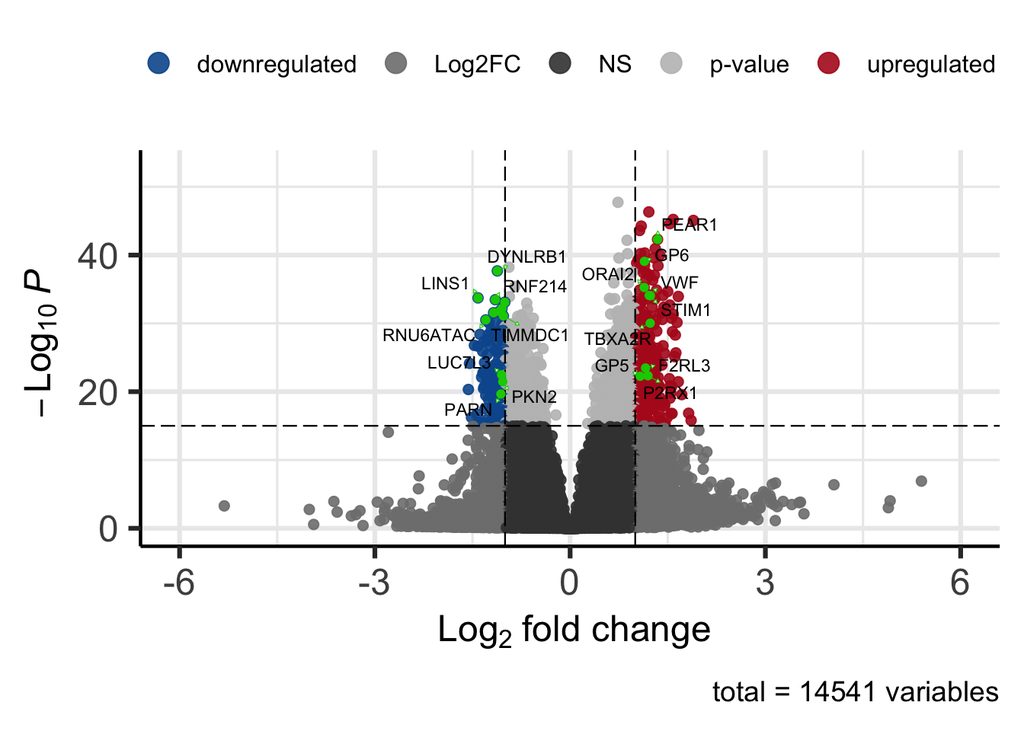

```r
top_10_downregulated_without_labs_of_interest <- as.character(downregulated_genes[!(downregulated_genes$hgnc_symbol %in% labs_of_interest),"hgnc_symbol"])[1:10]

plot <- myVolcanoPlot(dds_ccs_results,
                      data_type = "gene",
                      pCutoff = pCutoff,
                      FCcutoff = FCcutoff,
                      xlim = c(-6, 6),
                      lab_selection = c(regulated_labs_of_interest,
                                        top_10_downregulated_without_labs_of_interest))

ggsave(plot = plot, path ='plots', filename = paste0("CCS_only_volcano_regGenset_top10downreg", version, ".png"),
       width = plot_width, height = plot_height, dpi = plot_res, units = "in", device='png')
ggsave(plot = plot, path ='plots/pdf', filename = paste0("CCS_only_volcano_regGenset_top10downreg", version, ".pdf"),
       width = plot_width, height = plot_height, dpi = plot_res, units = "in", device='pdf')
plot
```

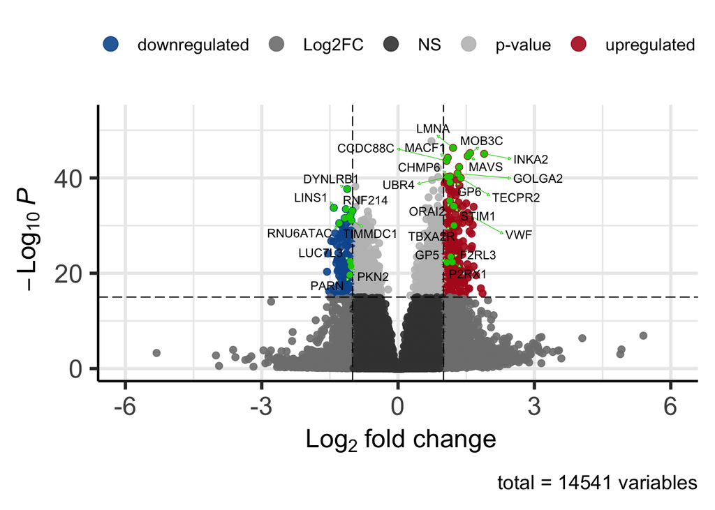

```r
plot <- myVolcanoPlot(dds_ccs_results,
                      data_type = "gene",
                      pCutoff = pCutoff,
                      FCcutoff = FCcutoff,
                      xlim = c(-6, 6),
                      lab_selection = c(regulated_labs_of_interest, top_10_upregulated_without_labs_of_interest,
                                        top_10_downregulated_without_labs_of_interest))

ggsave(plot = plot, path ='plots', filename = paste0("CCS_only_volcano_regGenset_top10up&downreg", version, ".png"),
       width = plot_width, height = plot_height, dpi = plot_res, units = "in", device='png')
ggsave(plot = plot, path ='plots/pdf', filename = paste0("CCS_only_volcano_regGenset_top10up&downreg", version, ".pdf"),
       width = plot_width, height = plot_height, dpi = plot_res, units = "in", device='pdf')
plot
```

## Gene onthology analysis

```r
#test
padj <- padj_thresholds <- 0.01
count <- count_thresholds <- 5
fdr <- fdr_thresholds <- 0.2


gos_of_interest <- c("platelet", "hemostasis", "coagulation")
#padj_thresholds <- c(0.1, 0.01, 0.05, 1e-15)
#count_thresholds <- c(2, 5, 10, 12, 15, 20)
#fdr_thresholds <- c(0.01, 0.05, 0.1, 0.2, 0.5, 0.75, 1)

for(padj in padj_thresholds){
  panther_result_up_ref <- fread(paste0("../data/GO_analysis/padj", padj,
                                    "/Panther_upregulatedGenes_ReferenceBackground_padj", padj, ".txt"))
  panther_result_down_ref <- fread(paste0("../data/GO_analysis/padj", padj,
                                      "/Panther_downregulatedGenes_ReferenceBackground_padj", padj, ".txt"))
  panther_result_up_human <- fread(paste0("../data/GO_analysis/padj", padj,
                                    "/Panther_upregulatedGenes_HumanBackground_padj", padj, ".txt"))
  panther_result_down_human <- fread(paste0("../data/GO_analysis/padj", padj,
                                      "/Panther_downregulatedGenes_HumanBackground_padj", padj, ".txt"))


  for(count in count_thresholds){
    for(fdr in fdr_thresholds){
      print(paste0("padj", padj, "_count", count, "_fdr", fdr))
      plot_ref <- myGObarplot(panther_result_up = panther_result_up_ref,
                              panther_result_down = panther_result_down_ref,
                              count_threshold = count,
                              fdr_threshold = fdr,
                              padj_threshold = padj,
                              gos_of_interest = gos_of_interest,
                              background = "Reference genes")
      plot_human <- myGObarplot(panther_result_up = panther_result_up_human,
                                panther_result_down = panther_result_down_human,
                                count_threshold = count,
                                fdr_threshold = fdr,
                                padj_threshold = padj,
                                gos_of_interest = gos_of_interest,
                                background = "All human genes")
      plot <- ggarrange(plot_ref, plot_human, ncol = 1, nrow = 2)
      ggsave(plot = plot, path = paste0("plots/padj", padj),
             filename = paste0("CCS_only_GOanalysis_padj", padj, "_count", count, "_fdr", fdr, version, ".png"),
             width = plot_width*3, height = plot_height*2, dpi = plot_res, units = "in", device='png')
    }
  }
}
```

```
## [1] "padj0.01_count5_fdr0.2"
```